[figure not shown]

# Application of Neural Networks

**Kannan Singaravelu**

kannan.singaravelu@fitchlearning.com

# Deep Sequence Modeling

Deep sequence modeling is essentially applying neural network to problems involving sequential processing of data. Sequence data has memory and comes in many forms such as text, audio, video and financial time series. Thus, requiring a different modeling approaches.

## Recurrent Neural Network

### Long Short Term Memory Network

Long Short Term Memory (LSTM) algorithm is a special kind of RNN, explicitly designed to avoid the long-term dependency problem by addressing the problem of short term memory. LSTM models are fundamental to deep learning for financial timeseries and have four interacting layers as given below

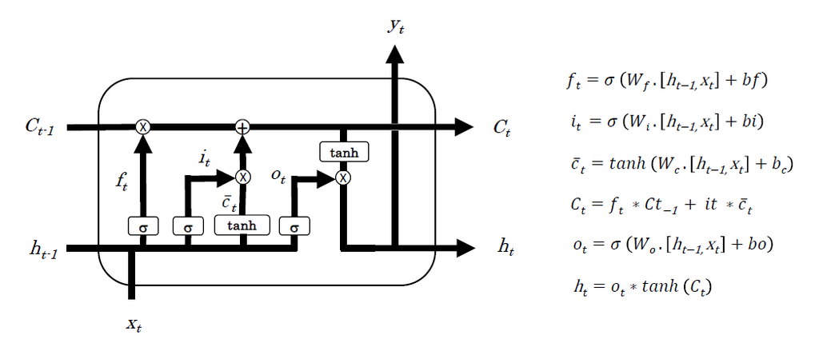

Diagrammatic Representation of LSTM cell and its operation <sup>[2]</sup>

## One-to-One Sequence Problem

In one-to-one sequence problem, there is a single input and a single ouput. We'll see two types of these sequence problem : (a) single feature and (b) multiple features. In type (a), each timestep has a single feature and in type (b), each timestep has multiple features.

We'll use LSTM network to the sequence problems.

```python
## Data Retrieval and Preprocessing
# Import required libraries
import pandas as pd
import numpy as np

# Import preprocessor from sklearn
from sklearn.preprocessing import MinMaxScaler
from sklearn.model_selection import train_test_split

# Import from keras
from keras.models import Sequential
from keras.utils.vis_utils import plot_model
from keras.layers import Dropout, Dense, LSTM

# Import cufflinks for visualization
import matplotlib.pyplot as plt
plt.rcParams['figure.figsize'] =(20,10)
plt.style.use('fivethirtyeight')

# Ignore warnings
import warnings
warnings.filterwarnings('ignore')
```

### Example 1 : One-to-One Single Feature

Let's prepare a sample dataset for a function $y=10*X$ which can be used for one-to-one sequence modeling. In the below script, we create 20 inputs and 20 outputs. Each input consists of one timestep, which in turn contains a single feature (X)

> The input of the LSTM is always is a 3D array *[`batch, timesteps, feature`]*  
> The output of the LSTM could be a 2D array or 3D array depending upon the return_sequences argument  
> If return_sequence is False, the output is a 2D array *[`batch, feature`]*  
> If return_sequence is True, the output is a 3D array *[`batch, timesteps, feature`]*

The `batch` is the number of samples in the input data (20 in this case), `timesteps` are the number of timesteps per sample (1 in this case) and `feature` correspond to the number of features per timestep (1 in this case).

```python
# create sample dataset
X = []
y = []

X = [i+1 for i in range(20)]
y = [i*10 for i in X]
```

```python
print(f'X: {X}')
print(f'y: {y}')
```

```
X: [1, 2, 3, 4, 5, 6, 7, 8, 9, 10, 11, 12, 13, 14, 15, 16, 17, 18, 19, 20]
y: [10, 20, 30, 40, 50, 60, 70, 80, 90, 100, 110, 120, 130, 140, 150, 160, 170, 180, 190, 200]
```

```python
# reshape into 3D
X = np.array(X).reshape(20,1,1)
```

```python
# check the shape
X.shape
```

```
(20, 1, 1)
```

```python
# convert to array
y = np.array(y)
```

```python
# check the shape
y.shape
```

```
(20,)
```

```python
# complie model one
model_one = Sequential()
model_one.add(LSTM(50, activation='relu', input_shape=(1,1)))
model_one.add(Dense(1))
model_one.compile(optimizer='adam', loss='mse')
print(model_one.summary())
```

```
Model: "sequential"
_________________________________________________________________
Layer (type)                 Output Shape              Param #
=================================================================
lstm (LSTM)                  (None, 50)                10400
_________________________________________________________________
dense (Dense)                (None, 1)                 51
=================================================================
Total params: 10,451
Trainable params: 10,451
Non-trainable params: 0
_________________________________________________________________
None
```

The `return_sequences` argument tells whether to return the output at each time step instead of the final time step. If we set the `return_sequences` to True, the output shape will become a 3D array, instead of a 2D array.

Let's train the model_one now.

```python
# fit model one
model_one.fit(X, y, batch_size=5, epochs=2000, validation_split=0.2, verbose=0)
```

```
<tensorflow.python.keras.callbacks.History at 0x1a41ee2a90>
```

```python
# predict the outcome
test_input = np.array([30])
test_input = test_input.reshape((1, 1, 1))
test_output = model_one.predict(test_input, verbose=0)
print(test_output)
```

```
[[293.7028]]
```

### Example 2: One-to-One Single Feature W/stacked LSTM

For the above function and dataset, let's now train our model with stacked LSTM layers.

```python
# complie model two
model_two = Sequential()
model_two.add(LSTM(50, activation='relu', return_sequences=True, input_shape=(1, 1)))
model_two.add(LSTM(50, activation='relu'))
model_two.add(Dense(1))
model_two.compile(optimizer='adam', loss='mse')
print(model_two.summary())
```

```
Model: "sequential_1"
_________________________________________________________________
Layer (type)                 Output Shape              Param #
=================================================================
lstm_1 (LSTM)                (None, 1, 50)             10400
_________________________________________________________________
lstm_2 (LSTM)                (None, 50)                20200
_________________________________________________________________
dense_1 (Dense)              (None, 1)                 51
=================================================================
Total params: 30,651
Trainable params: 30,651
Non-trainable params: 0
_________________________________________________________________
None
```

```python
# fit model two
model_two.fit(X, y, batch_size=5, epochs=2000, validation_split=0.2, verbose=0)
```

```
<tensorflow.python.keras.callbacks.History at 0x1a42982780>
```

```python
# predict the outcome
test_output = model_two.predict(test_input, verbose=0)
print(test_output)
```

```
[[297.79895]]
```

### Example 3: : One-to-One Multiple Feature

In the above examples, each input sample had one timestep where each timestep had one feature. In this example, we will model a one-to-one sequence problem when the input timesteps have multiple features.

```python
# create sample dataset
X1 = X2 = []
y = []

X1 = [2*(i+1) for i in range(20)]
X2 = [3*(i+1) for i in range(20)]
y = [i*j for i,j in zip(X1,X2)]
```

```python
print(f'X1: {X1}')
print(f'X2: {X2}')
print(f'y:  {y}')
```

```
X1: [2, 4, 6, 8, 10, 12, 14, 16, 18, 20, 22, 24, 26, 28, 30, 32, 34, 36, 38, 40]
X2: [3, 6, 9, 12, 15, 18, 21, 24, 27, 30, 33, 36, 39, 42, 45, 48, 51, 54, 57, 60]
y:  [6, 24, 54, 96, 150, 216, 294, 384, 486, 600, 726, 864, 1014, 1176, 1350, 1536, 1734, 1944, 2166, 2400]
```

```python
# create a feature matrix
X = np.column_stack((X1, X2))
print(X)
```

```
[[ 2  3]
 [ 4  6]
 [ 6  9]
 [ 8 12]
 [10 15]
 [12 18]
 [14 21]
 [16 24]
 [18 27]
 [20 30]
 [22 33]
 [24 36]
 [26 39]
 [28 42]
 [30 45]
 [32 48]
 [34 51]
 [36 54]
 [38 57]
 [40 60]]
```

```python
# reshape into 3D
X = np.array(X).reshape(20,1,2)
```

```python
# check the shape
X.shape
```

```
(20, 1, 2)
```

```python
# complie model three
model_three = Sequential()
model_three.add(LSTM(50, activation='relu', input_shape=(1, 2)))
model_three.add(Dense(10, activation='relu'))
model_three.add(Dense(1))
model_three.compile(optimizer='adam', loss='mse')
print(model_three.summary())
```

```
Model: "sequential_2"
_________________________________________________________________
Layer (type)                 Output Shape              Param #
=================================================================
lstm_3 (LSTM)                (None, 50)                10600
_________________________________________________________________
dense_2 (Dense)              (None, 10)                510
_________________________________________________________________
dense_3 (Dense)              (None, 1)                 11
=================================================================
Total params: 11,121
Trainable params: 11,121
Non-trainable params: 0
_________________________________________________________________
None
```

```python
# convert to array
y = np.array(y)
```

```python
print(y)
```

```
[   6   24   54   96  150  216  294  384  486  600  726  864 1014 1176
 1350 1536 1734 1944 2166 2400]
```

```python
# check the shape
y.shape
```

```
(20,)
```

```python
# fit model three
model_three.fit(X, y, batch_size=5, epochs=2000, validation_split=0.2, verbose=0)
```

```
<tensorflow.python.keras.callbacks.History at 0x1a3d3a5da0>
```

```python
# predict the outcome
test_input = np.array([55,80])
test_input = test_input.reshape((1, 1, 2))
test_output = model_three.predict(test_input, verbose=0)
print(test_output)
```

```
[[3421.0317]]
```

### Example 4: One-to-One Multiple Features W/stacked LSTM

For the above function and dataset, let's now train our model with stacked LSTM layers.

```python
# complie model four
model_four = Sequential()
model_four.add(LSTM(200, activation='relu', return_sequences=True, input_shape=(1, 2)))
model_four.add(LSTM(200, activation='relu'))
model_four.add(Dense(50, activation='relu'))
model_four.add(Dense(10, activation='relu'))
model_four.add(Dense(1))
model_four.compile(optimizer='adam', loss='mse')
print(model_four.summary())
```

```
Model: "sequential_3"
_________________________________________________________________
Layer (type)                 Output Shape              Param #
=================================================================
lstm_4 (LSTM)                (None, 1, 200)            162400
_________________________________________________________________
lstm_5 (LSTM)                (None, 200)               320800
_________________________________________________________________
dense_4 (Dense)              (None, 50)                10050
_________________________________________________________________
dense_5 (Dense)              (None, 10)                510
_________________________________________________________________
dense_6 (Dense)              (None, 1)                 11
=================================================================
Total params: 493,771
Trainable params: 493,771
Non-trainable params: 0
_________________________________________________________________
None
```

```python
# fit model four
model_four.fit(X, y, batch_size=5, epochs=2000, validation_split=0.2, verbose=0)
```

```
<tensorflow.python.keras.callbacks.History at 0x1a438b9400>
```

```python
# predict the outcome
test_output = model_four.predict(test_input, verbose=0)
print(test_output)
```

```
[[3387.1912]]
```

## Many-to-One Sequence Problem

Data with single time-step cannot be considered sequence data in a real sense. Densely connected neural networks have been proven to perform better with single time-step data. Real sequence data consists of multiple time-steps, such as stock prices of past $n$ days, a sentence containing multiple words, and so on.

In many-to-one sequence problems, each input sample has more than one timestep, however the output consists of a single element. Similar to the above examples, each timestep in the input can have one or more features.

### Example five : Many-to-One Single Feature

Let's prepare a sample dataset of 20 samples with 3 timesteps where each timestep will consist of a single feature. The output of each sample will be the sum of these 3 inputs. For example, if our sample consists of a sequence 1,2,3, the output would be 1+2+3 = 6.

```python
# create sample dataset
X = np.array([i+1 for i in range(60)])
```

```python
# reshape into 3D
X = np.array(X).reshape(20,3,1)
```

```python
print(f'X: {X}')
```

```
X: [[[ 1]
  [ 2]
  [ 3]]

 [[ 4]
  [ 5]
  [ 6]]

 [[ 7]
  [ 8]
  [ 9]]

 [[10]
  [11]
  [12]]

 [[13]
  [14]
  [15]]

 [[16]
  [17]
  [18]]

 [[19]
  [20]
  [21]]

 [[22]
  [23]
  [24]]

 [[25]
  [26]
  [27]]

 [[28]
  [29]
  [30]]

```

[output cut: 24 more lines]

```
 [[49]
  [50]
  [51]]

 [[52]
  [53]
  [54]]

 [[55]
  [56]
  [57]]

 [[58]
  [59]
  [60]]]
```

```python
# check the shape
X.shape
```

```
(20, 3, 1)
```

Next, we'll create output y, which is the sum of the values in the timesteps

```python
# y is the sum of the values in the timesteps
y = []
for each in X:
    y.append(each.sum())

# convert to array
y = np.array(y)

# check the output
print(f'y: {y}')
```

```
y: [  6  15  24  33  42  51  60  69  78  87  96 105 114 123 132 141 150 159
 168 177]
```

```python
# check the shape
y.shape
```

```
(20,)
```

```python
# complie model five
model_five = Sequential()
model_five.add(LSTM(50, activation='relu', input_shape=(3, 1)))
model_five.add(Dense(1))
model_five.compile(optimizer='adam', loss='mse')
print(model_five.summary())
```

```
Model: "sequential_4"
_________________________________________________________________
Layer (type)                 Output Shape              Param #
=================================================================
lstm_6 (LSTM)                (None, 50)                10400
_________________________________________________________________
dense_7 (Dense)              (None, 1)                 51
=================================================================
Total params: 10,451
Trainable params: 10,451
Non-trainable params: 0
_________________________________________________________________
None
```

```python
# fit model five
model_five.fit(X, y, batch_size=5, epochs=2000, validation_split=0.2, verbose=0)
```

```
<tensorflow.python.keras.callbacks.History at 0x1a443c6518>
```

```python
# predict the outcome
test_input = np.array([70,71,72])
test_input = test_input.reshape((1, 3, 1))
test_output = model_five.predict(test_input, verbose=0)
print(test_output)
```

```
WARNING:tensorflow:5 out of the last 5 calls to <function Model.make_predict_function.<locals>.predict_function at 0x1a448bef28> triggered tf.function retracing. Tracing is expensive and the excessive number of tracings could be due to (1) creating @tf.function repeatedly in a loop, (2) passing tens…
[[213.20935]]
```

## Applying Neural Networks to Financial Time Series

Given that we have some understanding of the above deep sequence modeling, let us know apply neural networks to financial timeseries which is a many-to-one sequence probalem.

### Retrieving the Data

```python
# Read stock data from the locally stored data
# df = pd.read_csv('/data/spy.csv', index_col=0, parse_dates=True)

df = pd.read_excel('../data/faang_stocks.xlsx', 'AAPL', index_col=0, parse_dates=True)

# Display the first five rows of the dataframe to check the results.
df.head()
```

| Date | AAPL |
| --- | --- |
| 2009-12-31 | 26.131752 |
| 2010-01-04 | 26.538483 |
| 2010-01-05 | 26.584366 |
| 2010-01-06 | 26.161509 |
| 2010-01-07 | 26.113146 |

```python
# Check for missing values
df.isna().sum()
```

```
AAPL    0
dtype: int64
```

```python
# Get the number of rows and column in the data set
df.shape
```

```
(2578, 1)
```

### Visualising the Data

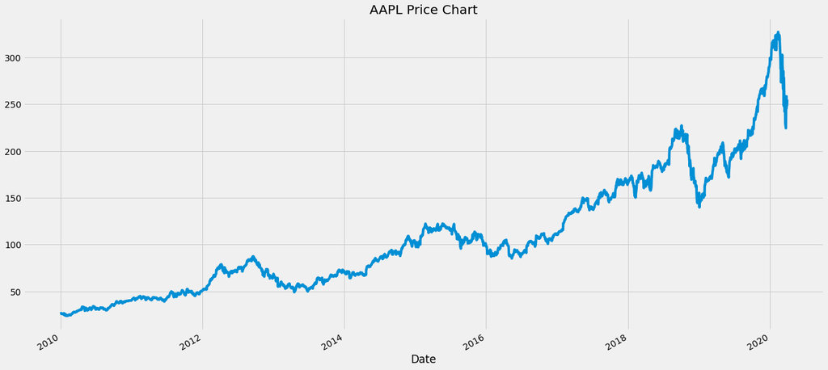

```python
# Visualize the data
plt.figure(figsize=(20,10))
plt.title('AAPL Price Chart')
df['AAPL'].plot();
```

The above graph shows different behaviors of stock prices over time. This will make our learning more robust as well as give us a chance to test how good the predictions are for various market regimes. And, it is prudent to perform data normalization given such wide range of the underlying stock price.

### Converting the DataFrame

We will convert the DataFrame to ndarray for our analysis

```python
# convert to numpy array
data = df.values
data
```

```
array([[ 26.13175201],
       [ 26.53848267],
       [ 26.58436584],
       ...,
       [258.44000244],
       [247.74000549],
       [254.80999756]])
```

```python
data.shape
```

```
(2578, 1)
```

### Normalizing the Dataset

Feature scaling helps the algorithm in converging the local/global minimum efficiently. Different time periods of data have different value ranges and hence we scale/normalize the data.

```python
# Splitting the datasets into training and testing data.
train_data, test_data = train_test_split(data, train_size=0.8, test_size=0.2, shuffle=False)

# Output the train and test data size
print(f"Train and Test Size {len(train_data)}, {len(test_data)}")
```

```
Train and Test Size 2062, 516
```

```python
# Scale the features MinMax for training and test datasets
scaler = MinMaxScaler()
scaled_train_data = scaler.fit_transform(train_data)
scaled_test_data = scaler.transform(test_data)

scaled_train_data
```

```
array([[0.01515328],
       [0.01781397],
       [0.01811413],
       ...,
       [0.96959791],
       [0.98893301],
       [1.        ]])
```

```python
# create X & y data array
X_train = []
y_train = []
timesteps = 60

for i in range(timesteps, len(scaled_train_data)):
    X_train.append(scaled_train_data[i-timesteps:i,0])
    y_train.append(scaled_train_data[i,0])

# Converting x_train and y_train to Numpy arrays
X_train, y_train = np.array(X_train), np.array(y_train)
```

```python
print(f'X_train: {X_train.shape}, y_train {y_train.shape}')
```

```
X_train: (2002, 60), y_train (2002,)
```

### Reshaping the Data

We need to reshape the data as LSTM network consume input in a 3-dimensional array in the form of number of samples, number of time steps and number of features, while our x_train data is a 2-dimensional array.

```python
# reshaping into 3D Array
X_train = np.reshape(X_train,(X_train.shape[0], X_train.shape[1], 1))

# check the array size
X_train.shape
```

```
(2002, 60, 1)
```

```python
# reshaping the label
y_train.shape
```

```
(2002,)
```

```python
X_train
```

```
array([[[0.01515328],
        [0.01781397],
        [0.01811413],
        ...,
        [0.02806761],
        [0.03151521],
        [0.03272386]],

       [[0.01781397],
        [0.01811413],
        [0.01534794],
        ...,
        [0.03151521],
        [0.03272386],
        [0.0355307 ]],

       [[0.01811413],
        [0.01534794],
        [0.01503157],
        ...,
        [0.03272386],
        [0.0355307 ],
        [0.03484117]],

       ...,

       [[0.91707611],
        [0.93797994],
        [0.93183546],
        ...,
        [0.9688348 ],
        [0.96788065],
        [0.95744979]],

       [[0.93797994],
        [0.93183546],
        [0.93544617],
        ...,
        [0.96788065],
        [0.95744979],
        [0.96959791]],

       [[0.93183546],
        [0.93544617],
        [0.93512945],
        ...,
        [0.95744979],
        [0.96959791],
        [0.98893301]]])
```

```python
X_train[0]
```

```
array([[1.51532816e-02],
       [1.78139735e-02],
       [1.81141254e-02],
       [1.53479387e-02],
       [1.50315664e-02],
       [1.61672427e-02],
       [1.46503125e-02],
       [1.27115150e-02],
       [1.50883502e-02],
       [1.40987321e-02],
       [1.12594788e-02],
       [1.86495353e-02],
       [1.59644505e-02],
       [1.29954092e-02],
       [4.62381987e-03],
       [8.93945245e-03],
       [1.12675890e-02],
       [1.28413155e-02],
       [5.87310130e-03],
       [8.17257769e-06],
       [2.17400548e-03],
       [3.09064429e-03],
       [5.82437777e-03],
       [0.00000000e+00],
       [2.76618672e-03],
       [1.67915902e-03],
       [3.35835548e-03],
       [2.49040277e-03],
       [5.37010722e-03],
       [6.75729935e-03],
       [9.20712621e-03],
       [8.51761020e-03],
       [8.82584739e-03],
       [7.80377609e-03],
       [6.78976507e-03],
       [4.06412931e-03],
       [6.98445958e-03],
       [8.07144984e-03],
       [1.01968067e-02],
       [1.37417464e-02],
       [1.36281913e-02],
       [1.40175553e-02],
       [1.51370238e-02],
       [2.18213813e-02],
       [2.19268014e-02],
       [2.51229530e-02],
       [2.65993572e-02],
       [2.71347671e-02],
       [2.80271003e-02],
       [2.57881135e-02],
       [2.62829849e-02],
       [2.60152737e-02],
       [2.64452012e-02],
       [2.44983435e-02],
       [2.65263406e-02],
       [2.94548060e-02],
       [3.02740601e-02],
       [2.80676138e-02],
       [3.15152064e-02],
       [3.27238620e-02]])
```

```python
# verify the timesteps
len(X_train[0])
```

```
60
```

### Building a LSTM Model

First, we define the LSTM Recurrent Neural Network by initializing the **Sequential** Model. We'll add more **LSTM** layers and adjust the **Dropout** in order to improve the accuracy of our model. Finally, a **Dense** layer is used as output layer.

Next, we compile and train the model defined above. Iteratively, we can increase or decrease the epochs and batch size to get more accuracy.

### Define the Model

```python
# Instantiate the Sequential Model
model = Sequential()

# Add first layer with dropout regularisation with 100 neurons and inputs shape for 1st set
model.add(LSTM(units=256, input_shape = (X_train.shape[1],X_train.shape[2]), return_sequences=True))
model.add(Dropout(0.4))

# Add second layer with dropout
model.add(LSTM(units=256, return_sequences=False))
model.add(Dropout(0.4))

# Add a Dense layer
model.add(Dense(64,  activation = 'relu'))

# Add the output layer
model.add(Dense(1))

# Print model summary
print(model.summary())
```

```
Model: "sequential_5"
_________________________________________________________________
Layer (type)                 Output Shape              Param #
=================================================================
lstm_7 (LSTM)                (None, 60, 256)           264192
_________________________________________________________________
dropout (Dropout)            (None, 60, 256)           0
_________________________________________________________________
lstm_8 (LSTM)                (None, 256)               525312
_________________________________________________________________
dropout_1 (Dropout)          (None, 256)               0
_________________________________________________________________
dense_8 (Dense)              (None, 64)                16448
_________________________________________________________________
dense_9 (Dense)              (None, 1)                 65
=================================================================
Total params: 806,017
Trainable params: 806,017
Non-trainable params: 0
_________________________________________________________________
None
```

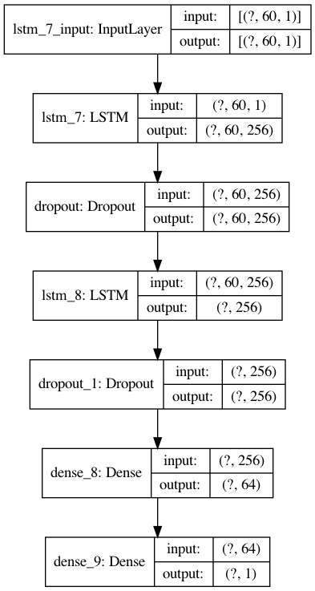

```python
# Plot the LSTM model
plot_model(model, to_file='../images/lstm_plot.png', show_shapes=True, show_layer_names=True)
```

```python
# Get model weights
for lay in model.layers:
    print(lay.name)
    print(lay.get_weights())
```

[output not shown]

[output cut: 72 more lines]

[output not shown]

### Compiling the Model

```python
# Compiling the model
model.compile(optimizer='adam', loss='mean_squared_error')
```

### Fitting the Model

```python
# Training the model to the training dataset
history = model.fit(X_train, y_train, batch_size=64, epochs=20, verbose=1, validation_split=0.05, shuffle=False)
```

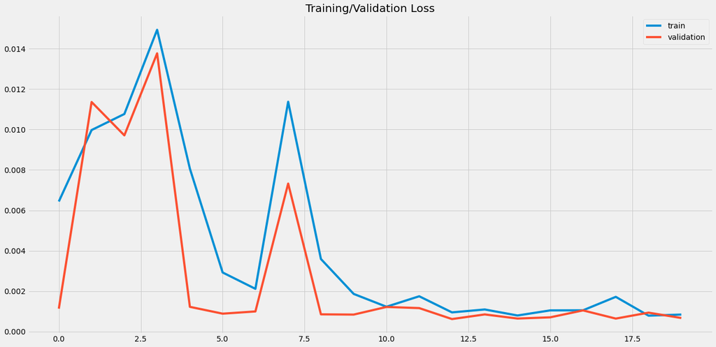

```python
# Visualize the training and validation loss
plt.plot(history.history['loss'], label='train')
plt.plot(history.history['val_loss'], label='validation')
plt.legend()
plt.title('Training/Validation Loss');
```

```python
# Evaluate the model >> model.metrics_names
print(f'{model.metrics_names}: {model.evaluate(X_train, y_train , verbose=1)}')
```

```
['loss']: 0.00041486689588055015
```

### Prediction

Now that the model is trained, it needs to be tested on the test dataset.

```python
# Building the array
X_test = []
y_test = test_data[60:]
timesteps = 60

for i in range(timesteps, len(scaled_test_data)):
    X_test.append(scaled_test_data[i-timesteps:i,0])

# Converting x_train and y_train to Numpy arrays
X_test = np.array(X_test)

# Reshaping into 3D Array
X_test = np.reshape(X_test,(X_test.shape[0], X_test.shape[1], 1))

# Check the array size
X_test.shape
```

```
(456, 60, 1)
```

```python
# Scale the data by transforming
y_pred = model.predict(X_test)
predicted_price = scaler.inverse_transform(y_pred)
```

[output not shown]

```python
# Get the root mean squared error (RMSE)
rmse = np.sqrt(np.mean(predicted_price - y_test)**2)
rmse
```

```
8.22335798698513
```

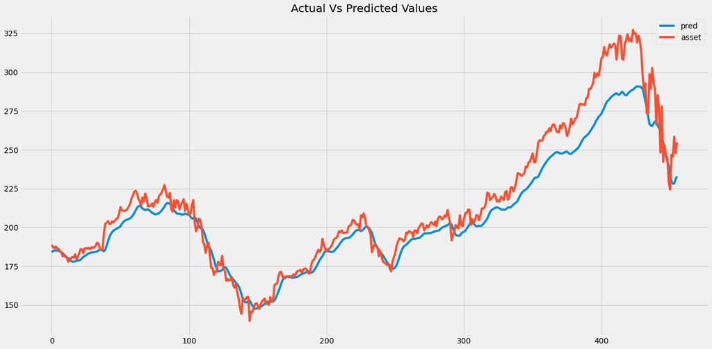

```python
# Plot prediction vs actual price
plt.plot(predicted_price, label='pred')
plt.plot(y_test, label='asset')
plt.legend()
plt.title('Actual Vs Predicted Values');
```

## References

[1] Andrej Karpathy (2015), The Unreasonable Effectiveness of Recurrent Neural Networks

[2] Kannan Singaravelu (2020), Introduction to Deep Learning & Neural Networks, Lecture Slide #84

[3] [Keras API Documentaion](https://keras.io)

[4] [TensorFlow API Documentation](https://www.tensorflow.org)

[5] [Scikit-Learn Preprocessing](https://scikit-learn.org/stable/modules/generated/sklearn.preprocessing.MinMaxScaler.html)

[6] Francois Chollet (2019), Deep Learning with Python

Kannan Singaravelu  
https://github.com/kannansingaravelu  
Certificate in Quantitative Finance, June 2020